# Unsupervised learning for Consumer behaviour and marketing analysis

Stephanie Omwanda

# Introduction

> Kira Plastinina is a Russian brand that is sold through a defunct chain of retail stores in Russia, Ukraine, Kazakhstan, Belarus, China, Philippines, and Armenia. The brand’s Sales and Marketing team would like to understand their customer’s behavior from data that they have collected over the past year. More specifically, they would like to learn the characteristics of customer groups.

# Research Question

# Understanding the context

> The dataset can be found here [ http://bit.ly/EcommerceCustomersDataset ]. The dataset consists of 10 numerical and 8 categorical attributes. The ‘Revenue’ attribute can be used as the class label. “Administrative”, “Administrative Duration”, “Informational”, “Informational Duration”, “Product Related” and “Product Related Duration” represents the number of different types of pages visited by the visitor in that session and total time spent in each of these page categories. The values of these features are derived from the URL information of the pages visited by the user and updated in real-time when a user takes an action, e.g. moving from one page to another. The “Bounce Rate”, “Exit Rate” and “Page Value” features represent the metrics measured by “Google Analytics” for each page in the e-commerce site. The value of the “Bounce Rate” feature for a web page refers to the percentage of visitors who enter the site from that page and then leave (“bounce”) without triggering any other requests to the analytics server during that session The value of the “Exit Rate” feature for a specific web page is calculated as for all pageviews to the page, the percentage that was the last in the session. The “Page Value” feature represents the average value for a web page that a user visited before completing an e-commerce transaction. The “Special Day” feature indicates the closeness of the site visiting time to a specific special day (e.g. Mother’s Day, Valentine’s Day) in which the sessions are more likely to be finalized with the transaction. The value of this attribute is determined by considering the dynamics of e-commerce such as the duration between the order date and delivery date. For example, for Valentina’s day, this value takes a nonzero value between February 2 and February 12, zero before and after this date unless it is close to another special day, and its maximum value of 1 on February 8. The dataset also includes the operating system, browser, region, traffic type, visitor type as returning or new visitor, a Boolean value indicating whether the date of the visit is weekend, and month of the year

# Metric of Success

> The model’s accuracy score is what will be used to measure the model’s predictive power.

# Loading and Cleaning the dataset

```r
 # load libraries
library(readr) # provides a faster and friendly way to read rectangular data like csvs
library(dplyr) # provides a flexible grammar of data manipulation library(tinytex)
library(knitr) # for dynamic report generation
options(warn = -1)
```

```r
# Loading the csv file
df = read_csv('online_shoppers_intention.csv')
```

```r
# Previewing the first five rows of the dataframe
head(df)
```

| Administrative | Administrative_Duration | Informational | Informational_Duration | ProductRelated | ProductRelated_Duration | BounceRates | ExitRates | PageValues | SpecialDay | Month | OperatingSystems | Browser | Region | TrafficType | VisitorType | Weekend | Revenue |
| --- | --- | --- | --- | --- | --- | --- | --- | --- | --- | --- | --- | --- | --- | --- | --- | --- | --- |
| 0 | 0 | 0 | 0 | 1 | 0.000000 | 0.20000000 | 0.2000000 | 0 | 0 | Feb | 1 | 1 | 1 | 1 | Returning_Visitor | FALSE | FALSE |
| 0 | 0 | 0 | 0 | 2 | 64.000000 | 0.00000000 | 0.1000000 | 0 | 0 | Feb | 2 | 2 | 1 | 2 | Returning_Visitor | FALSE | FALSE |
| 0 | -1 | 0 | -1 | 1 | -1.000000 | 0.20000000 | 0.2000000 | 0 | 0 | Feb | 4 | 1 | 9 | 3 | Returning_Visitor | FALSE | FALSE |
| 0 | 0 | 0 | 0 | 2 | 2.666667 | 0.05000000 | 0.1400000 | 0 | 0 | Feb | 3 | 2 | 2 | 4 | Returning_Visitor | FALSE | FALSE |
| 0 | 0 | 0 | 0 | 10 | 627.500000 | 0.02000000 | 0.0500000 | 0 | 0 | Feb | 3 | 3 | 1 | 4 | Returning_Visitor | TRUE | FALSE |
| 0 | 0 | 0 | 0 | 19 | 154.216667 | 0.01578947 | 0.0245614 | 0 | 0 | Feb | 2 | 2 | 1 | 3 | Returning_Visitor | FALSE | FALSE |

```r
# show structure of  dataset
str(df)
```

```
Classes ‘spec_tbl_df’, ‘tbl_df’, ‘tbl’ and 'data.frame':    12330 obs. of  18 variables:
 $ Administrative         : num  0 0 0 0 0 0 0 1 0 0 ...
 $ Administrative_Duration: num  0 0 -1 0 0 0 -1 -1 0 0 ...
 $ Informational          : num  0 0 0 0 0 0 0 0 0 0 ...
 $ Informational_Duration : num  0 0 -1 0 0 0 -1 -1 0 0 ...
 $ ProductRelated         : num  1 2 1 2 10 19 1 1 2 3 ...
 $ ProductRelated_Duration: num  0 64 -1 2.67 627.5 ...
 $ BounceRates            : num  0.2 0 0.2 0.05 0.02 ...
 $ ExitRates              : num  0.2 0.1 0.2 0.14 0.05 ...
 $ PageValues             : num  0 0 0 0 0 0 0 0 0 0 ...
 $ SpecialDay             : num  0 0 0 0 0 0 0.4 0 0.8 0.4 ...
 $ Month                  : chr  "Feb" "Feb" "Feb" "Feb" ...
 $ OperatingSystems       : num  1 2 4 3 3 2 2 1 2 2 ...
 $ Browser                : num  1 2 1 2 3 2 4 2 2 4 ...
 $ Region                 : num  1 1 9 2 1 1 3 1 2 1 ...
 $ TrafficType            : num  1 2 3 4 4 3 3 5 3 2 ...
 $ VisitorType            : chr  "Returning_Visitor" "Returning_Visitor" "Returning_Visitor" "Returning_Visitor" ...
 $ Weekend                : logi  FALSE FALSE FALSE FALSE TRUE FALSE ...
 $ Revenue                : logi  FALSE FALSE FALSE FALSE FALSE FALSE ...
 - attr(*, "spec")=
  .. cols(
  ..   Administrative = col_double(),
  ..   Administrative_Duration = col_double(),
  ..   Informational = col_double(),
  ..   Informational_Duration = col_double(),
  ..   ProductRelated = col_double(),
  ..   ProductRelated_Duration = col_double(),
  ..   BounceRates = col_double(),
  ..   ExitRates = col_double(),
  ..   PageValues = col_double(),
  ..   SpecialDay = col_double(),
  ..   Month = col_character(),
  ..   OperatingSystems = col_double(),
  ..   Browser = col_double(),
  ..   Region = col_double(),
  ..   TrafficType = col_double(),
  ..   VisitorType = col_character(),
  ..   Weekend = col_logical(),
  ..   Revenue = col_logical()
  .. )
```

```r
# catch a glimpse of the dataset
glimpse(df)
```

```
Observations: 12,330
Variables: 18
$ Administrative          <dbl> 0, 0, 0, 0, 0, 0, 0, 1, 0, 0, 0, 0, 0, 0, 0, 2, 0, 0, 0, 0, 0, 0, 0, 0, 0, …
$ Administrative_Duration <dbl> 0.0, 0.0, -1.0, 0.0, 0.0, 0.0, -1.0, -1.0, 0.0, 0.0, 0.0, 0.0, 0.0, 0.0, 0.…
$ Informational           <dbl> 0, 0, 0, 0, 0, 0, 0, 0, 0, 0, 0, 0, 0, 0, 0, 0, 0, 0, 0, 0, 0, 0, 0, 0, 0, …
$ Informational_Duration  <dbl> 0, 0, -1, 0, 0, 0, -1, -1, 0, 0, 0, 0, 0, 0, 0, 0, -1, 0, 0, 0, 0, -1, 0, 0…
$ ProductRelated          <dbl> 1, 2, 1, 2, 10, 19, 1, 1, 2, 3, 3, 16, 7, 6, 2, 23, 1, 13, 2, 20, 8, 1, 3, …
$ ProductRelated_Duration <dbl> 0.000000, 64.000000, -1.000000, 2.666667, 627.500000, 154.216667, -1.000000…
$ BounceRates             <dbl> 0.200000000, 0.000000000, 0.200000000, 0.050000000, 0.020000000, 0.01578947…
$ ExitRates               <dbl> 0.200000000, 0.100000000, 0.200000000, 0.140000000, 0.050000000, 0.02456140…
$ PageValues              <dbl> 0.00000, 0.00000, 0.00000, 0.00000, 0.00000, 0.00000, 0.00000, 0.00000, 0.0…
$ SpecialDay              <dbl> 0.0, 0.0, 0.0, 0.0, 0.0, 0.0, 0.4, 0.0, 0.8, 0.4, 0.0, 0.4, 0.0, 0.0, 0.0, …
$ Month                   <chr> "Feb", "Feb", "Feb", "Feb", "Feb", "Feb", "Feb", "Feb", "Feb", "Feb", "Feb"…
$ OperatingSystems        <dbl> 1, 2, 4, 3, 3, 2, 2, 1, 2, 2, 1, 1, 1, 2, 3, 1, 1, 1, 2, 2, 2, 3, 3, 2, 2, …
$ Browser                 <dbl> 1, 2, 1, 2, 3, 2, 4, 2, 2, 4, 1, 1, 1, 5, 2, 1, 1, 1, 2, 4, 2, 3, 2, 4, 2, …
$ Region                  <dbl> 1, 1, 9, 2, 1, 1, 3, 1, 2, 1, 3, 4, 1, 1, 3, 9, 4, 1, 1, 4, 5, 1, 1, 1, 4, …
$ TrafficType             <dbl> 1, 2, 3, 4, 4, 3, 3, 5, 3, 2, 3, 3, 3, 3, 3, 3, 3, 4, 3, 4, 1, 3, 5, 3, 1, …
$ VisitorType             <chr> "Returning_Visitor", "Returning_Visitor", "Returning_Visitor", "Returning_V…
$ Weekend                 <lgl> FALSE, FALSE, FALSE, FALSE, TRUE, FALSE, FALSE, TRUE, FALSE, FALSE, FALSE, …
$ Revenue                 <lgl> FALSE, FALSE, FALSE, FALSE, FALSE, FALSE, FALSE, FALSE, FALSE, FALSE, FALSE…
```

```r
# checking for the statistical summary
summary(df)
```

```
 Administrative   Administrative_Duration Informational    Informational_Duration ProductRelated
 Min.   : 0.000   Min.   :  -1.00         Min.   : 0.000   Min.   :  -1.00        Min.   :  0.00
 1st Qu.: 0.000   1st Qu.:   0.00         1st Qu.: 0.000   1st Qu.:   0.00        1st Qu.:  7.00
 Median : 1.000   Median :   8.00         Median : 0.000   Median :   0.00        Median : 18.00
 Mean   : 2.318   Mean   :  80.91         Mean   : 0.504   Mean   :  34.51        Mean   : 31.76
 3rd Qu.: 4.000   3rd Qu.:  93.50         3rd Qu.: 0.000   3rd Qu.:   0.00        3rd Qu.: 38.00
 Max.   :27.000   Max.   :3398.75         Max.   :24.000   Max.   :2549.38        Max.   :705.00
 NA's   :14       NA's   :14              NA's   :14       NA's   :14             NA's   :14
 ProductRelated_Duration  BounceRates         ExitRates         PageValues        SpecialDay
 Min.   :   -1.0         Min.   :0.000000   Min.   :0.00000   Min.   :  0.000   Min.   :0.00000
 1st Qu.:  185.0         1st Qu.:0.000000   1st Qu.:0.01429   1st Qu.:  0.000   1st Qu.:0.00000
 Median :  599.8         Median :0.003119   Median :0.02512   Median :  0.000   Median :0.00000
 Mean   : 1196.0         Mean   :0.022152   Mean   :0.04300   Mean   :  5.889   Mean   :0.06143
 3rd Qu.: 1466.5         3rd Qu.:0.016684   3rd Qu.:0.05000   3rd Qu.:  0.000   3rd Qu.:0.00000
 Max.   :63973.5         Max.   :0.200000   Max.   :0.20000   Max.   :361.764   Max.   :1.00000
 NA's   :14              NA's   :14         NA's   :14
    Month           OperatingSystems    Browser           Region       TrafficType    VisitorType
 Length:12330       Min.   :1.000    Min.   : 1.000   Min.   :1.000   Min.   : 1.00   Length:12330
 Class :character   1st Qu.:2.000    1st Qu.: 2.000   1st Qu.:1.000   1st Qu.: 2.00   Class :character
 Mode  :character   Median :2.000    Median : 2.000   Median :3.000   Median : 2.00   Mode  :character
                    Mean   :2.124    Mean   : 2.357   Mean   :3.147   Mean   : 4.07
                    3rd Qu.:3.000    3rd Qu.: 2.000   3rd Qu.:4.000   3rd Qu.: 4.00
                    Max.   :8.000    Max.   :13.000   Max.   :9.000   Max.   :20.00

  Weekend         Revenue
 Mode :logical   Mode :logical
 FALSE:9462      FALSE:10422
 TRUE :2868      TRUE :1908
```

```r
 # determine the dimensions of the dataset
dim(df)
```

```
[1] 12330    18
```

> From the chunk above, it is evident that the dataset contains 12,330 observations of 18 variables

```r
# checking if there exists null values by calculating the sum of the null values p er column
colSums((is.na(df)))
```

```
         Administrative Administrative_Duration           Informational  Informational_Duration
                     14                      14                      14                      14
         ProductRelated ProductRelated_Duration             BounceRates               ExitRates
                     14                      14                      14                      14
             PageValues              SpecialDay                   Month        OperatingSystems
                      0                       0                       0                       0
                Browser                  Region             TrafficType             VisitorType
                      0                       0                       0                       0
                Weekend                 Revenue
                      0                       0
```

> We can see that about 8 variables have the same number of missing values

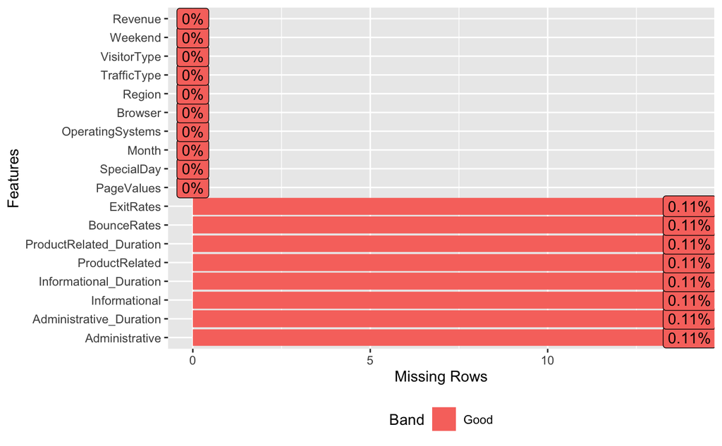

```r
# a plot showing missing values
library(DataExplorer) # simplifies and automates EDA processes and aids in report generation
plot_missing(df)
```

```r
# Dropping missing values
df = na.omit(df)
```

```r
colSums((is.na(df)))
```

```
         Administrative Administrative_Duration           Informational  Informational_Duration
                      0                       0                       0                       0
         ProductRelated ProductRelated_Duration             BounceRates               ExitRates
                      0                       0                       0                       0
             PageValues              SpecialDay                   Month        OperatingSystems
                      0                       0                       0                       0
                Browser                  Region             TrafficType             VisitorType
                      0                       0                       0                       0
                Weekend                 Revenue
                      0                       0
```

> The missing values have been successfully omitted

```r
# Checking for duplicated data
anyDuplicated(df)
```

```
[1] 159
```

> The dataset is seen to contain a number of duplicates which will mess up with analysis and the prediction model, they will therefore be dealt with in th next chunk

```r
# Dropping duplicates
df = distinct(df)

# confirming whether the drop was successful
anyDuplicated(df)
```

```
[1] 0
```

> Our dataset if now free of redundant data.

```r
# Checking the type of the dataset
class(df)
```

```
[1] "tbl_df"     "tbl"        "data.frame"
```

```r
# Changing the type of the loaded dataset to a dataframe
df = as.data.frame(df)
class(df)
```

```
[1] "data.frame"
```

```r
library(magrittr) # offers a set of operators that provide semantics that will improve code
# Checking the datatypes for each column
columns = colnames(df)
for (column in seq(length(colnames(df)))){
    print(columns[column])
    print(class(df[, column]))
    cat('\n')
}
```

```
[1] "Administrative"
[1] "numeric"

[1] "Administrative_Duration"
[1] "numeric"

[1] "Informational"
[1] "numeric"

[1] "Informational_Duration"
[1] "numeric"

[1] "ProductRelated"
[1] "numeric"

[1] "ProductRelated_Duration"
[1] "numeric"

[1] "BounceRates"
[1] "numeric"

[1] "ExitRates"
[1] "numeric"

[1] "PageValues"
[1] "numeric"

[1] "SpecialDay"
[1] "numeric"

[1] "Month"
[1] "character"

[1] "OperatingSystems"
[1] "numeric"

[1] "Browser"
[1] "numeric"

[1] "Region"
[1] "numeric"

[1] "TrafficType"
[1] "numeric"

[1] "VisitorType"
[1] "character"

[1] "Weekend"
[1] "logical"

[1] "Revenue"
[1] "logical"
```

```r
# Cleaning column names, by making them uniform
colnames(df) = tolower(colnames(df))
```

> Now that our dataset is free of missing values and duplicates, we will go ahead and do a visual check on outliers in the dataset

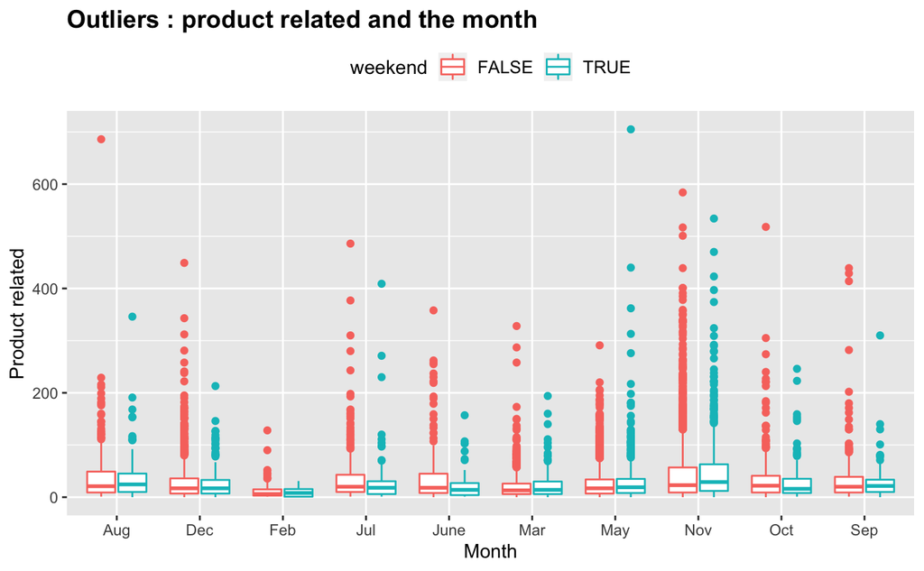

```r
library(ggplot2) # aids in creation of data visuals with the help of grammar of graphics
# Plotting boxplots
options(repr.plot.width = 11, repr.plot.height = 5)
ggplot(df, aes(month, productrelated, col = weekend)) +
  geom_boxplot() +
  labs(x = 'Month', y = 'Product related', title = 'Outliers : product related and the month') +
  theme(legend.position = 'top', legend.text = element_text(size = 10),
       plot.title = element_text(size = 14, color = 'black', face = 'bold'))
```

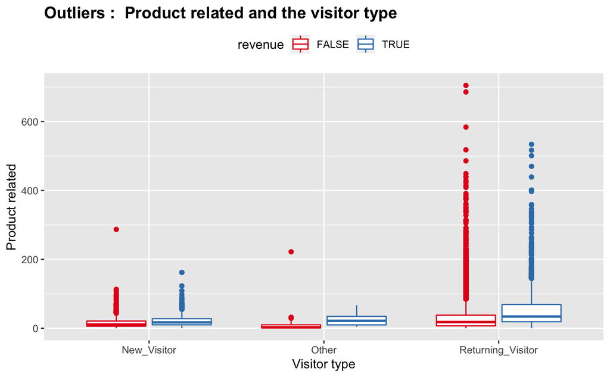

```r
# Plotting boxplots to check for outliers
options(repr.plot.width = 7, repr.plot.height = 5)
ggplot(df, aes(visitortype, productrelated, col = revenue)) +
  geom_boxplot() +
  labs(x = 'Visitor type', y = 'Product related', title = 'Outliers :  Product related and the visitor type') +
  scale_color_brewer(palette = 'Set1') +
  theme(legend.position = 'top',
       plot.title = element_text(size = 14, color = 'black', face ='bold'))
```

# Exploraroty data analyisis

> This is where we explore the data so as to: * maximize insights on the data set * uncover underlying structure * extract important variables * test underlying assumptions * develop models with great explanatory predictive power * determine optimal factor settings

> Here we will perform : * univariate analysis * bivariate analysis * multivariate analysis

> In EDA we have both graphical and non-graphical anaylyis , where non graphical contains Measures of central tendancies :(Mean, mode and median for numerical data and Mode for categorical data) and Measures of dispersion. Because the summary function did most of the non graphical analysis, this section will be densley populated with visaulizations and their analyses

## Univariate analysis

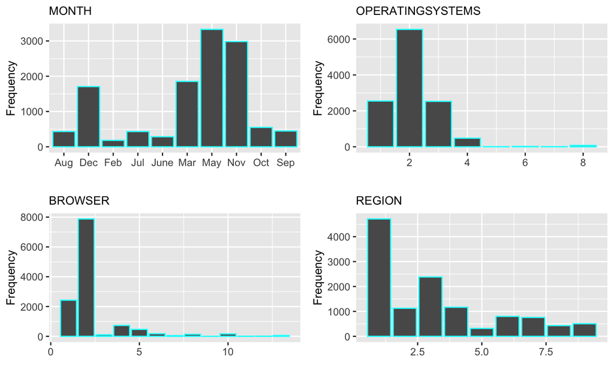

```r
library(gridExtra) # provides a number of user level functions to work with grid graphics

# Plotting bar plots showing frequency for each of variables
# we will plot the first 4  in this current chunk then the next for on the next chunk to avoid crampling up and untidyness

fac_cols = c('month', 'operatingsystems',   'browser',  'region')

columns = colnames(select(df, fac_cols))

p = list()
options(repr.plot.width = 10, repr.plot.height = 6)
for (i in 1:4){
  p[[i]] = ggplot(df, aes_string(columns[i])) + geom_bar(color = 'cyan') + labs(y = 'Frequency', x = '', title = toupper(columns[i])) +
  theme(plot.title = element_text(size = 10),
       axis.title.y = element_text(size = 10))
}

do.call(grid.arrange, p)
```

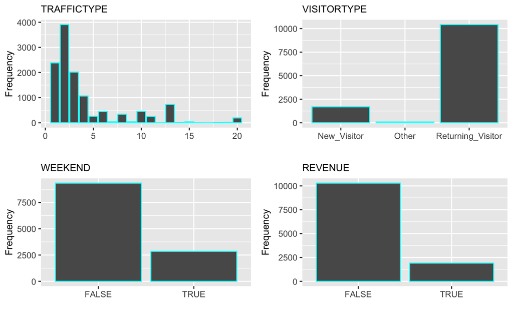

```r
fac_cols_2 = c('traffictype',   'visitortype',  'weekend',  'revenue')

columns_2 = colnames(select(df, fac_cols_2))

p_2 = list()
options(repr.plot.width = 10, repr.plot.height = 6)
for (i in 1:4){
  p_2[[i]] = ggplot(df, aes_string(columns_2[i])) + geom_bar(color = 'cyan') + labs(y = 'Frequency', x = '', title = toupper(columns_2[i])) +
  theme(plot.title = element_text(size = 10),
       axis.title.y = element_text(size = 10))
}

do.call(grid.arrange, p_2)
```

> Now that we have seen the frequency of each column in the dataset, we will check for their distribution and determine whether they are negatively or positively skewed

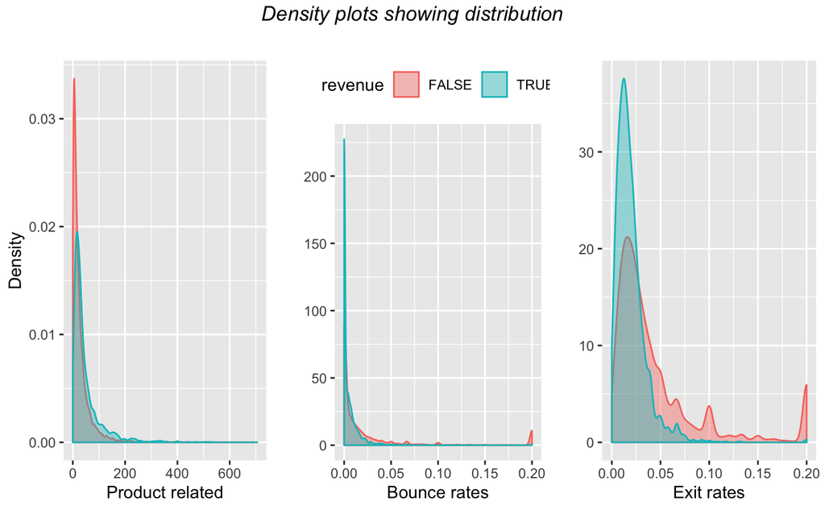

```r
library(grid)
# Plotting density plots to check for distributions
options(repr.plot.width = 11, repr.plot.height = 5)
p1 = ggplot(df, aes(productrelated, col = revenue)) +
  geom_density(aes(fill = revenue), alpha = 0.4) +
  labs(x = 'Product related', y = 'Density', title = '') +
  theme(legend.position = 'none',
       plot.title = element_text(size = 12))

p2 = ggplot(df, aes(bouncerates, col = revenue)) +
  geom_density(aes(fill = revenue), alpha = 0.4) +
  labs(x = 'Bounce rates', y = '', title = '') +
  theme(legend.position = 'top')

p3 = ggplot(df, aes(exitrates, col = revenue)) +
  geom_density(aes(fill = revenue), alpha = 0.4) +
  labs(x = 'Exit rates', y = '', title = '') +
  theme(legend.position = 'none',
       plot.title = element_text(size = 12))

grid.arrange(p1, p2, p3, ncol = 3, top = textGrob("Density plots showing distribution",gp=gpar(fontsize=13,font=3, color = 'black')))
```

> So far, the variables we are working with are all positvely skewed

## Bivariate analyisis

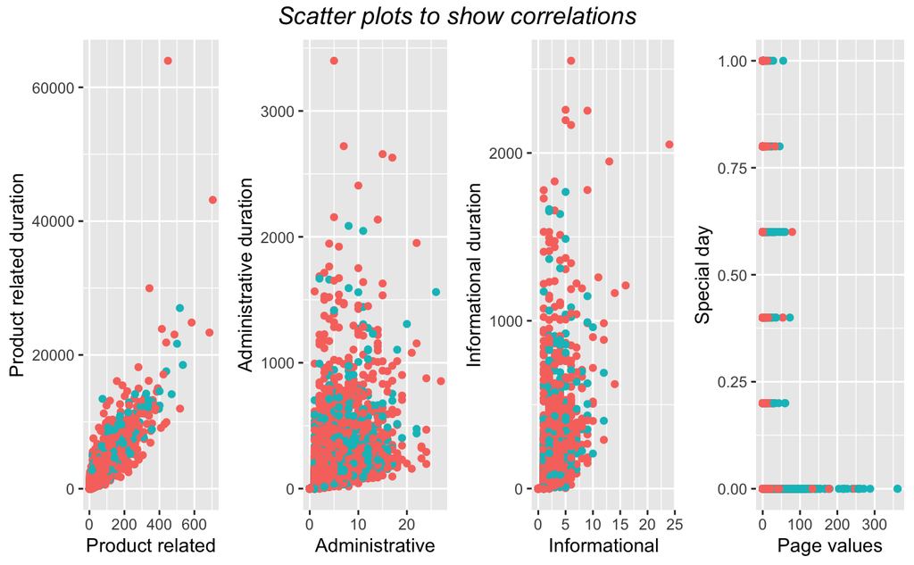

```r
# Plotting scatter plots to check for correlations
options(repr.plot.width = 11, repr.plot.height = 5)

p1 = ggplot(df, aes(productrelated, productrelated_duration, col = revenue)) +
    geom_point() + theme(legend.position = 'none') +
    labs(x='Product related', y ='Product related duration')

p2 = ggplot(df, aes(administrative, administrative_duration, col = revenue)) +
    geom_point() + theme(legend.position = 'none') +
    labs(x = 'Administrative', y = 'Administrative duration')

p3 = ggplot(df, aes(informational, informational_duration, col = revenue)) +
    geom_point() + theme(legend.position = 'none') +
    labs(x = 'Informational', y = 'Informational duration')

p4 = ggplot(df, aes(pagevalues, specialday  , col = revenue)) +
    geom_point() + theme(legend.position = 'none') +
    labs(x = 'Page values', y = 'Special day')

grid.arrange(p1, p2, p3, p4, ncol = 4,
             top = textGrob("Scatter plots to show correlations",gp=gpar(fontsize=14,font=3, color = 'darkmagenta')))
```

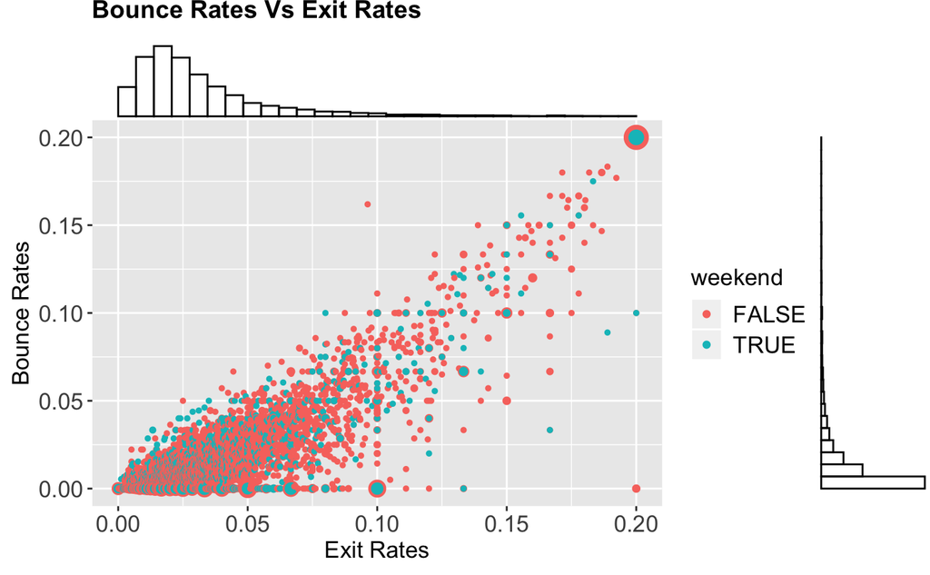

```r
library (ggExtra) # used to add marginal histograms, densityplots and boxplots scatter plots

# Plotting scatterplot with marginal density plots (default) or histograms using ggMarginal

options(repr.plot.width = 7, repr.plot.height = 5)

g = ggplot(data =df, aes(x =exitrates, y = bouncerates, col = weekend)) +
    geom_count(show.legend=c(size=FALSE)) +
    labs(title = 'Bounce Rates Vs Exit Rates', y = 'Bounce Rates', x = 'Exit Rates') +
    theme(plot.title = element_text(size = 14, face = 'bold'),
             axis.title.x = element_text(size = 13),
             axis.title.y = element_text(size = 13),
             axis.text.x = element_text(size = 13),
             axis.text.y = element_text(size = 13),
             legend.title = element_text(size = 13),
             legend.text = element_text(size = 13))

ggMarginal(g, type = "histogram", fill="transparent")
```

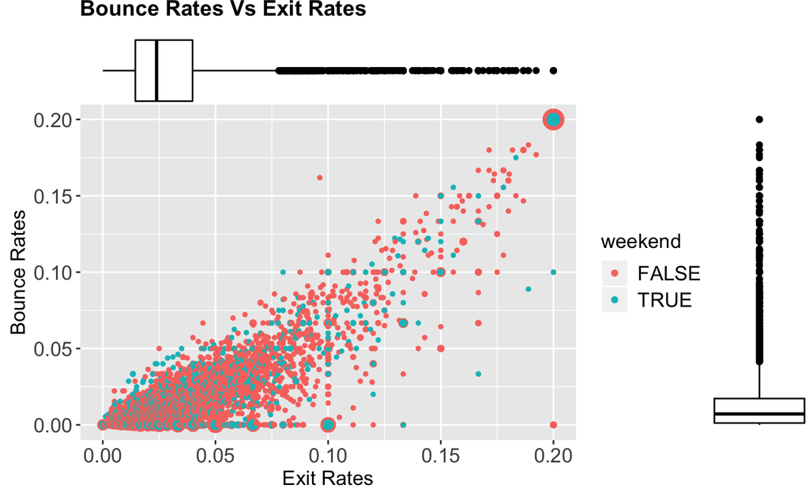

```r
ggMarginal(g, type = "boxplot", fill="transparent")
```

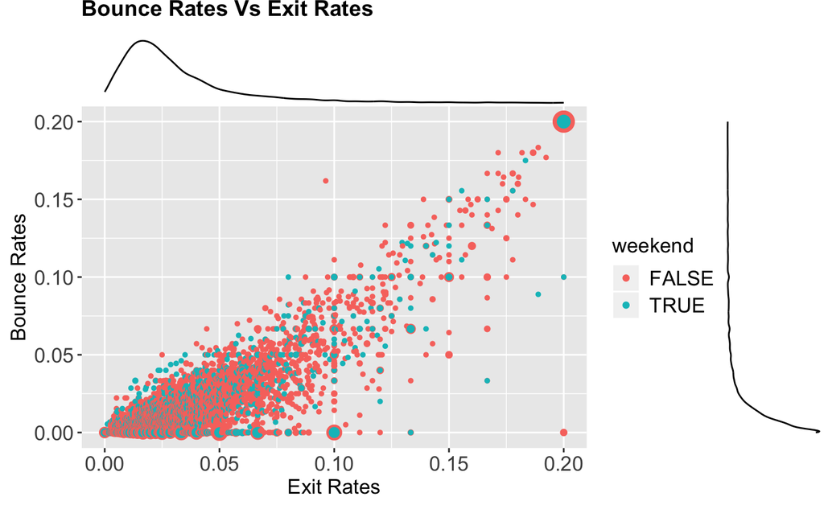

```r
ggMarginal(g, type = "density", fill="transparent")
```

## Multivariate analysis

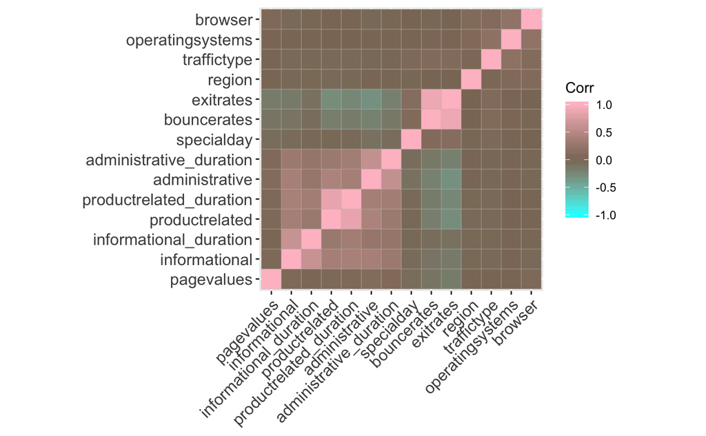

```r
library(ggcorrplot)
# Plotting a correlogram to check for correlations among all th features
options(repr.plot.width = 6, repr.plot.height = 5)

corr = round(cor(select_if(df, is.numeric)), 2)
ggcorrplot(corr, hc.order = T, ggtheme = ggplot2::theme_gray,
   colors = c("cyan", "peachpuff4", "pink"), lab = F)
```

> Now that we have created visual representations of how the dataset looks like we will go ahead and perfom analyses and create the models we need to make the best predictions

# K-Means

> Because K-means is a type unsupervised-learning, the class attribute is not needed for the execution of the algorithm. In the ‘Understanding the Context’ section, we mentioned that the ‘Revenue’ attribute will be used as the class label. It will be removed and stored in another variable. Afterwards we can normalize the attributes left.

```r
# creating a new dataframe
df.new <- df[,c(1:17)]
colnames(df.new)
```

```
 [1] "administrative"          "administrative_duration" "informational"           "informational_duration"
 [5] "productrelated"          "productrelated_duration" "bouncerates"             "exitrates"
 [9] "pagevalues"              "specialday"              "month"                   "operatingsystems"
[13] "browser"                 "region"                  "traffictype"             "visitortype"
[17] "weekend"
```

```r
# storing the class attribute in another variable
df.class <- df["revenue"]
colnames(df.class)
```

```
[1] "revenue"
```

```r
# Normalising the data so that no particular attribute has more impact on clustering than others
normalize <- function(x){
  return ((x-min(x)) / (max(x)-min(x)))
}
df.new$administrative <- normalize(df.new$administrative)
df.new$administrative_duration <- normalize(df.new$administrative_duration)
df.new$infromational <- normalize(df.new$informational)
df.new$infromational_duration <- normalize(df.new$informational_duration)
df.new$productrelated <- normalize(df.new$productrelated)
df.new$productrelated_duration <- normalize(df.new$productrelated_duration)
df.new$bouncerates<- normalize(df.new$bouncerates)
df.new$exitrates<- normalize(df.new$exitrates)
df.new$pagevalues<- normalize(df.new$pagevalues)
df.new$specialday<- normalize(df.new$specialday)
df.new$opertaingsystem<- normalize(df.new$operatingsystems)
df.new$browser<- normalize(df.new$browser)
df.new$region<- normalize(df.new$region)
df.new$traffictype<- normalize(df.new$traffictype)

head(df)
```

|  | administrative | administrative_duration | informational | informational_duration | productrelated | productrelated_duration | bouncerates | exitrates | pagevalues | specialday | month | operatingsystems | browser | region | traffictype | visitortype | weekend | revenue |
| --- | --- | --- | --- | --- | --- | --- | --- | --- | --- | --- | --- | --- | --- | --- | --- | --- | --- | --- |
| 1 | 0 | 0 | 0 | 0 | 1 | 0.000000 | 0.20000000 | 0.2000000 | 0 | 0 | Feb | 1 | 1 | 1 | 1 | Returning_Visitor | FALSE | FALSE |
| 2 | 0 | 0 | 0 | 0 | 2 | 64.000000 | 0.00000000 | 0.1000000 | 0 | 0 | Feb | 2 | 2 | 1 | 2 | Returning_Visitor | FALSE | FALSE |
| 3 | 0 | -1 | 0 | -1 | 1 | -1.000000 | 0.20000000 | 0.2000000 | 0 | 0 | Feb | 4 | 1 | 9 | 3 | Returning_Visitor | FALSE | FALSE |
| 4 | 0 | 0 | 0 | 0 | 2 | 2.666667 | 0.05000000 | 0.1400000 | 0 | 0 | Feb | 3 | 2 | 2 | 4 | Returning_Visitor | FALSE | FALSE |
| 5 | 0 | 0 | 0 | 0 | 10 | 627.500000 | 0.02000000 | 0.0500000 | 0 | 0 | Feb | 3 | 3 | 1 | 4 | Returning_Visitor | TRUE | FALSE |
| 6 | 0 | 0 | 0 | 0 | 19 | 154.216667 | 0.01578947 | 0.0245614 | 0 | 0 | Feb | 2 | 2 | 1 | 3 | Returning_Visitor | FALSE | FALSE |

```r
NA
```

```r
# Storing numeric values in a new variable
df.clust <- df.new [,c("administrative","administrative_duration","informational","informational_duration","productrelated","productrelated_duration","bouncerates","exitrates","pagevalues","specialday","operatingsystems","browser","region","traffictype")]

# Apply k means clustering algorithm with a number of centroids k
result<- kmeans(df.clust,3)
```

```r
# preview the number of records in each cluster

result$size
```

```
[1]   116 11530   553
```

```r
# get the value of cluster center datapoint value(k centers for k)
result$centers
```

```
  administrative administrative_duration informational informational_duration productrelated
1     0.22701149              0.08298299     4.4655172             1156.40264     0.14458303
2     0.07877357              0.02160253     0.3204683                8.72358     0.04184225
3     0.22182037              0.06867505     3.6057866              344.04175     0.10038347
  productrelated_duration bouncerates exitrates pagevalues specialday operatingsystems    browser    region
1              0.08241265  0.04112800 0.1182392 0.01846520 0.03793103         2.120690 0.10991379 0.2198276
2              0.01701258  0.10601490 0.2132804 0.01603853 0.06374675         2.125412 0.11389853 0.2709128
3              0.04471927  0.03621331 0.1053481 0.02469705 0.03001808         2.103074 0.09885473 0.2429928
  traffictype
1   0.1279492
2   0.1632081
3   0.1400019
```

```r
# getting cluster vector that shows the cluster where each record falls
result$cluster
```

[output not shown]

```r
# visualize the clustering results
par(mfrow = c(2,2), mar = c(5,4,2,2))
```

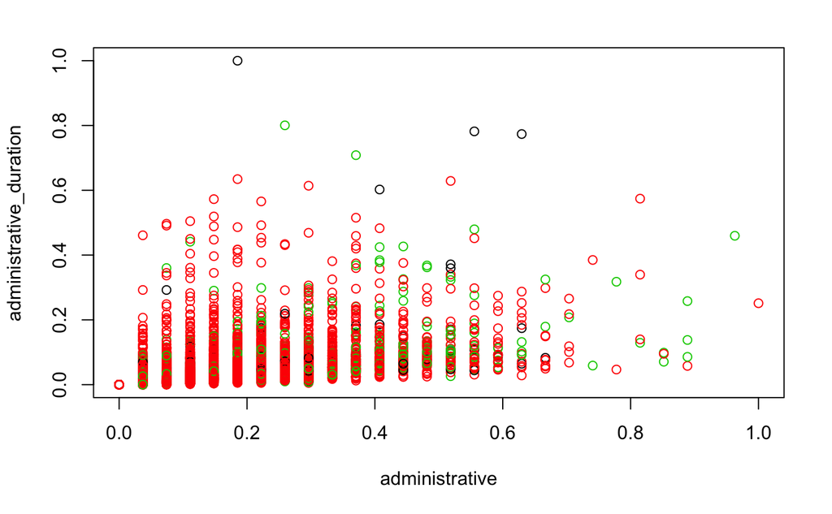

```r
# Plot dist in clusters
plot(df.clust[c(1,2)], col = result$cluster)
```

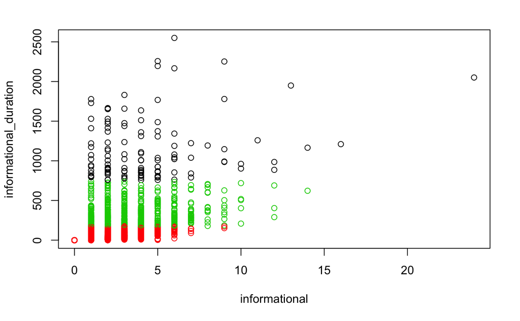

```r
# Plot dist in clusters
plot(df.clust[c(3,4)], col = result$cluster)
```

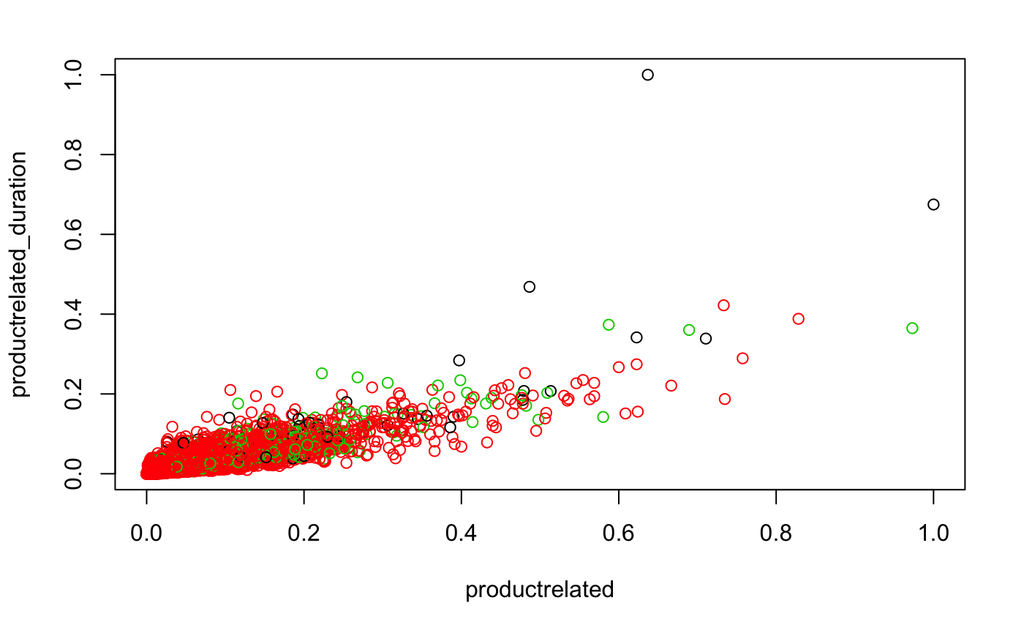

```r
# Plot dist in clusters
plot(df.clust[c(5,6)], col = result$cluster)
```

```r
NA
NA
```

```r
df.class[] <- lapply(df.class, as.numeric)
sapply(df.class,class)
```

```
  revenue
"numeric"
```

```r
#install.packages('useful')
#library(useful)

#df.clust[] <- lapply(df.clust, as.numeric)
#plot(df.clust[c(1,2)], col = df.class)
```

```r
# result table
#table(result$cluster,df.class)
```

```r
# accuracy score
mean(df.new == result$cluster)
```

```
[1] 0.02897779
```

# Hierachical Clustering

```r
# Compute descriptive stats
desc_stats <- data.frame(
  Min = apply(df.clust, 2, min),    # minimum
  Med = apply(df.clust, 2, median), # median
  Mean = apply(df.clust, 2, mean),  # mean
  SD = apply(df.clust, 2, sd),      # Standard deviation
  Max = apply(df.clust, 2, max)     # Maximum
)
desc_stats <- round(desc_stats, 1)
head(desc_stats)
```

|  | Min | Med | Mean | SD | Max |
| --- | --- | --- | --- | --- | --- |
| administrative | 0 | 0 | 0.1 | 0.1 | 1.0 |
| administrative_duration | 0 | 0 | 0.0 | 0.1 | 1.0 |
| informational | 0 | 0 | 0.5 | 1.3 | 24.0 |
| informational_duration | -1 | 0 | 34.8 | 141.5 | 2549.4 |
| productrelated | 0 | 0 | 0.0 | 0.1 | 1.0 |
| productrelated_duration | 0 | 0 | 0.0 | 0.0 | 1.0 |

```r
# scale the datafarm to make the variables comparable
# entails transforming variables such that they have a mean of 0 and std dev of 1
# because we dont want the hierachical clustering result to depend on an arbitrary variable unit

df.clust <- scale(df.clust)
head(df.clust)
```

```
     administrative administrative_duration informational informational_duration productrelated
[1,]     -0.7025315              -0.4601081    -0.3988128             -0.2462725     -0.6963635
[2,]     -0.7025315              -0.4601081    -0.3988128             -0.2462725     -0.6739424
[3,]     -0.7025315              -0.4657410    -0.3988128             -0.2533417     -0.6963635
[4,]     -0.7025315              -0.4601081    -0.3988128             -0.2462725     -0.6739424
[5,]     -0.7025315              -0.4601081    -0.3988128             -0.2462725     -0.4945739
[6,]     -0.7025315              -0.4601081    -0.3988128             -0.2462725     -0.2927843
     productrelated_duration  bouncerates  exitrates pagevalues specialday operatingsystems    browser
[1,]              -0.6289343  3.954699721  3.4273070 -0.3190356 -0.3103105       -1.2396607 -0.7939682
[2,]              -0.5955997 -0.450343788  1.2650121 -0.3190356 -0.3103105       -0.1371074 -0.2093703
[3,]              -0.6294551  3.954699721  3.4273070 -0.3190356 -0.3103105        2.0679992 -0.7939682
[4,]              -0.6275453  0.650917089  2.1299300 -0.3190356 -0.3103105        0.9654459 -0.2093703
[5,]              -0.3020990 -0.009839437  0.1838646 -0.3190356 -0.3103105        0.9654459  0.3752276
[6,]              -0.5486101 -0.102577188 -0.3661929 -0.3190356 -0.3103105       -0.1371074 -0.2093703
         region traffictype
[1,] -0.8962939 -0.76562243
[2,] -0.8962939 -0.51660683
[3,]  2.4336556 -0.26759123
[4,] -0.4800502 -0.01857564
[5,] -0.8962939 -0.01857564
[6,] -0.8962939 -0.26759123
```

```r
# clustering
# use the R function hclust() for hierarchical clustering
# 1st use dist() function to compute the Euclidean Distance btwn observs
# d will be the 1st argument in the hclust() function dissimilarity matrix

d<-dist(df.clust,method = "euclidean")
res.hc <- hclust (d,method = "ward.D2")
```

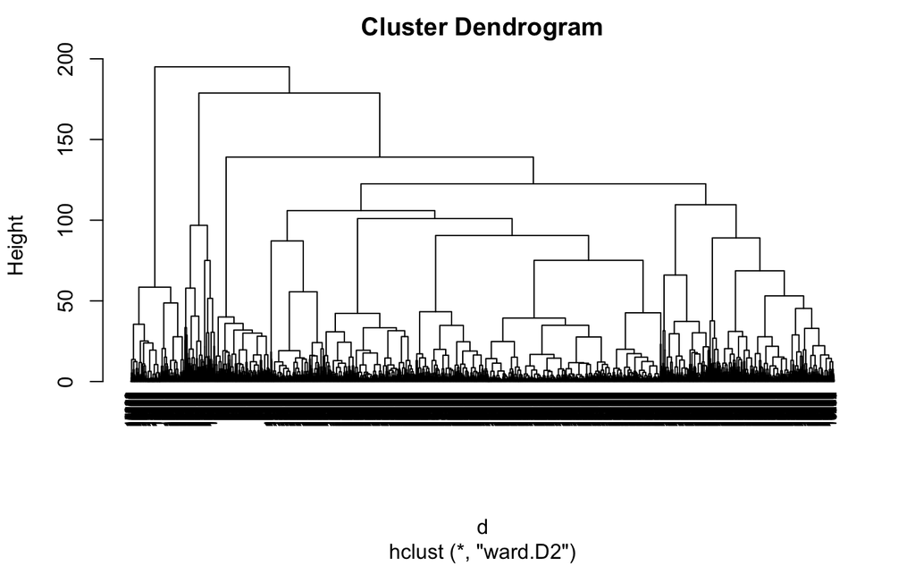

```r
# plot obtained dendogram
plot(res.hc,cex = 0.6,hang = -1)
```

```r
# checking for accuracy
mean(df.clust== result$cluster)
```

```
[1] 0
```